# Drug Clearance time study on Anti-asthma Drug

Tidybiology Final Project

2022-11-02

**Created by: Courtney Manning**

### Introduction

Theophylline is an anti-asthma medication. In this study there were 12 subjects who were given a single dose of 300 mg of theophylline orally, and the concentration of the drug was checked 11 times over a period of 25 hours. Unfortunately, the plasma level in blood varies considerably between patients, this can be due to differences in drug clearance, which is affected by body mass, age, smoking, liver and heart function, and viral infections. To complicate this drug further, it has important interactions with a number of other common medicines which can increase or decrease the drug level.

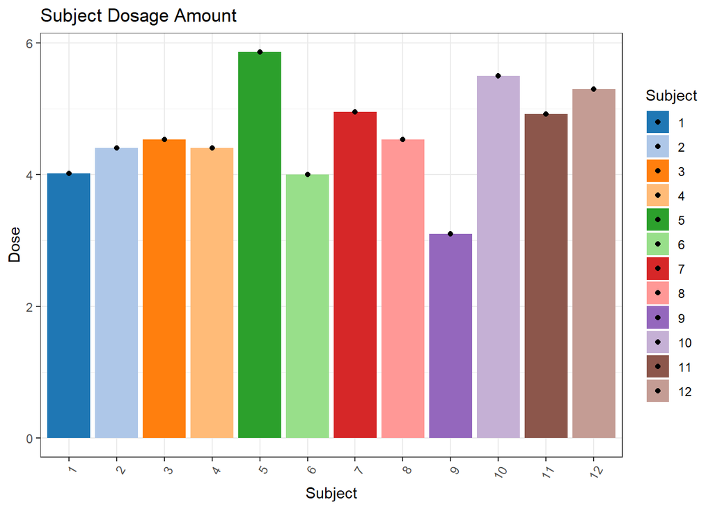

**Figure 1** - Subjects dosage amount of theophylline at beginning of study (mcg/kg)

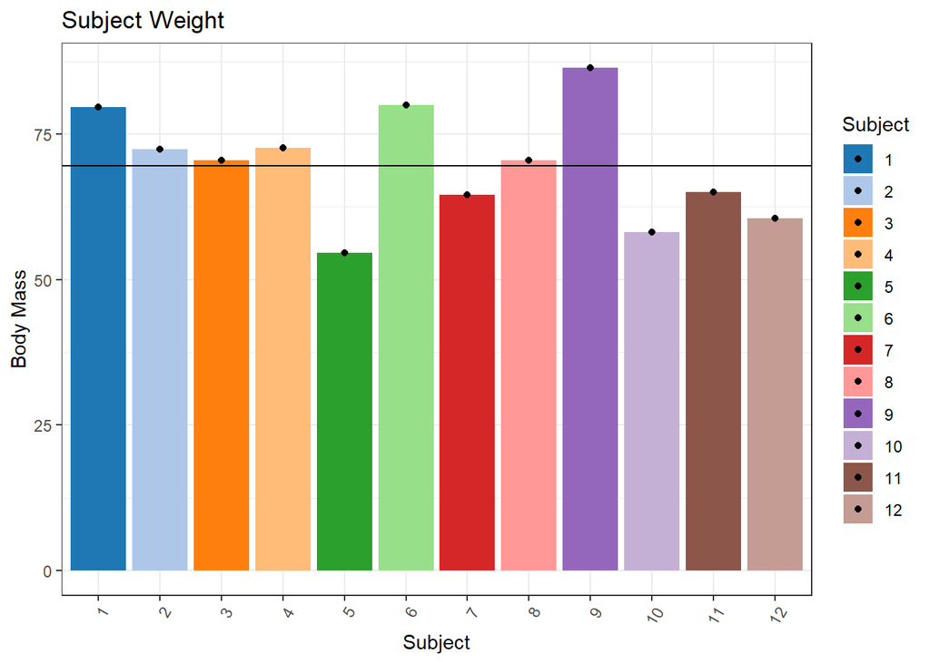

**Figure 2** - Subjects weight was calculated once in the study and the black line represents the average body mass of the subjects(kg)

### Results

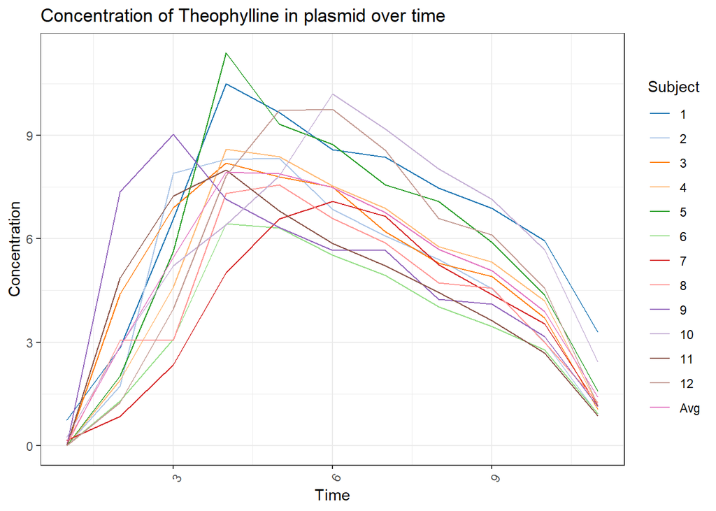

**Figure 3** - The concentration of theophylline is tested 11 times over a 25 hour period for each subject (mcg/mL). An average concentration is also calculated to create a control subject in this study.

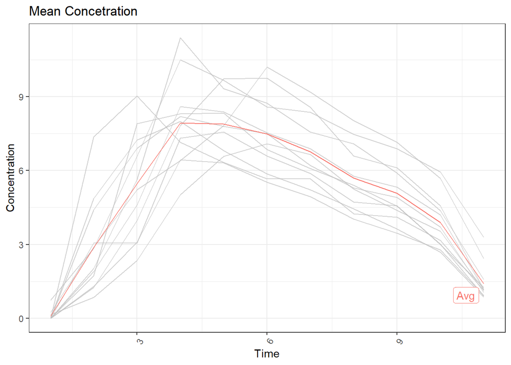

**Figure 4** - mean concentration over the study period. Operates as the average control subject in this study

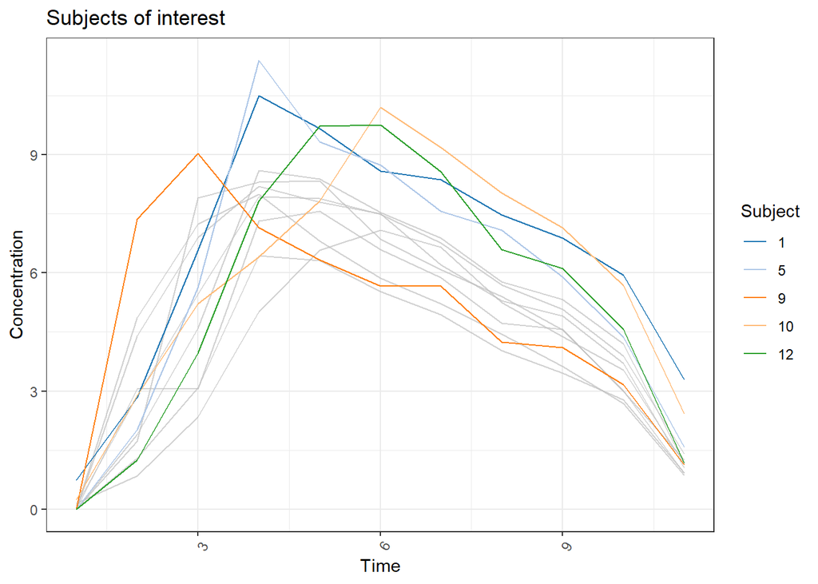

**Figure 5** - Subjects of interest in drug clearance study.

### Does body mass play a major role in drug clearance?

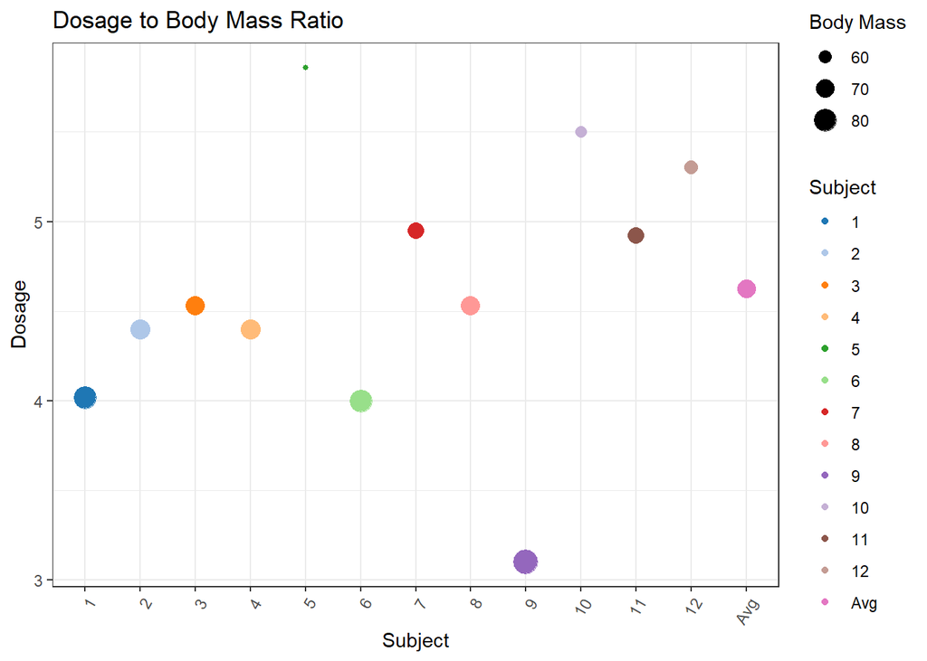

**Figure 6** - Dosage of theophylline of each subject in comparison to respective body mass